IMDB Movie Rating Final Project

```r
library(tidyverse)
library(broom)
library(ggplot2)
```

```r
data <- read.csv("../data/movie_metadata.csv")
view(data)
```

The first part of data cleaning involves removal of spurious characters (Â) from a the movie title, genre and plot keyword columns. This could have come up during data scrapping from the net.

Then we remove the duplicates in the data, using then “movie_title” column. Duplicate data will skew our analysis hence needs to be removed.

Third part of data cleaning is the currency columns. The “Budget” and “Gross” (revenue) columns for a few countries were not converted to USD while compiling the data. Hence we have done this manually. This cleaning will help us compare these financial columns across movies and countries. All the currency rates were taken from (http://www.xe.com/) as of November 2022.

Lastly we created a profit_flag column, which is 1 if the movie is profitable (Revenue > Budget) and 0 otherwise.

```r
data$movie_title <- (sapply(data$movie_title,gsub,pattern="\\Â",replacement=""))
data$genres_2 <- (sapply(data$genres,gsub,pattern="\\|",replacement=" "))
data$plot_keywords_2 <- (sapply(data$plot_keywords,gsub,pattern="\\|",replacement=" "))

data = data[!duplicated(data$movie_title),]

data <- transform(data, budget = ifelse(country == "South Korea", budget/1335.19, budget))
data <- transform(data, budget = ifelse(country == "Japan", budget/139.11, budget))
data <- transform(data, budget = ifelse(country == "Turkey", budget/18.61, budget))
data <- transform(data, budget = ifelse(country == "Hungary", budget/392.69, budget))
data <- transform(data, budget = ifelse(country == "Thailand", budget/35.69, budget))


data <- transform(data, gross = ifelse(country == "South Korea", gross/1335.19, gross))
data <- transform(data, gross = ifelse(country == "Japan", gross/139.11, gross))
data <- transform(data, gross = ifelse(country == "Turkey", gross/18.61, gross))
data <- transform(data, gross = ifelse(country == "Hungary", gross/392.69, gross))
data <- transform(data, gross = ifelse(country == "Thailand", gross/35.69, gross))


data$profit_flag <- as.factor(ifelse((data$gross > data$budget),1,0))

view(data)
```

Each movie in our dataset had more than one genre, hence some cleaning and genre separation was required. Some pre-built functions in the TM package were very useful. In short, in the Analysis of Genre, the following was done: 1. Cleaning of the Genre Variable 2. Converting Genre variable to Corpus 3. Frequency Analysis: See which are the most used genres in a movie

Drama, Comedy and Thriller are the top movie genres, as shown in the below Word-Cloud and Bar-Chart

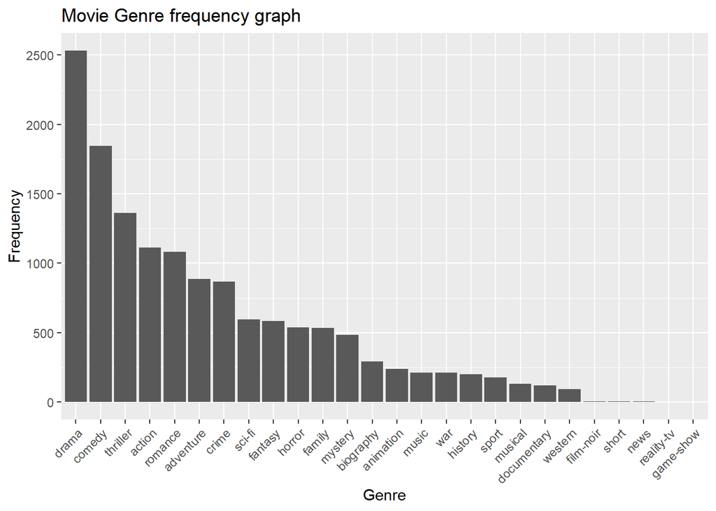

```r
library(tm)
library(dplyr)
library(ggplot2)
library(wordcloud)
library(plyr)
genre <- Corpus(VectorSource(data$genres_2))
genre_dtm <- DocumentTermMatrix(genre)
genre_freq <- colSums(as.matrix(genre_dtm))
freq <- sort(colSums(as.matrix(genre_dtm)), decreasing=TRUE)
genre_wf <- data.frame(word=names(genre_freq), freq=genre_freq)


ggplot(genre_wf, aes(x=reorder(word,-freq), y=freq))+
  geom_bar(stat="identity")+
  theme(axis.text.x=element_text(angle=45, hjust=1))+
  ggtitle("Movie Genre frequency graph")+
  xlab("Genre")+
  ylab("Frequency") +
  labs(alt = "Bar graph of Movie Genre frequency where drama is the most common")
```

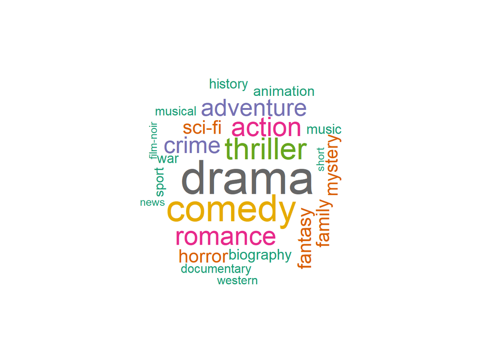

```r
set.seed(10)
pal2 <- brewer.pal(8,"Dark2")
wordcloud(genre_wf$word,genre_wf$freq,random.order=FALSE,
          rot.per=.15, colors=pal2,scale=c(4,.9),
          title="WordCloud: Movie Genres")
```

# Exploratory Data Analysis

We have explored the budget variable in the proposal and the genre variable in the previous parts which are some of the explanatory variables that we think that they should be included in the model for predicting the movie rating. In this part we will perform more Exploratory Data Analysis (EDA) to help us understand the data better moving to the modeling part.

## Summary statistics

The first step of EDA is to create the summary statistics of the dataset by calling the summary function. The following the summary statistics table provides the information about the minimum, first quantile, median, mean, third quantile, maximum, and the number of NaN value of each variable. Mean and median are the measure of central tendency.

Comparing them gives us the idea of the distribution without using the visualization. If the mean and median is close to each other, the distribution is normal. For example the difference between the mean and median is small, then the duration data is normally distributed. If the mean is higher than the median, the distribution is right-skewed. In this case, the actor_1_facebook_likes is right-skewed because the mean is much higher than the median.

```r
summary(data)
```

```
##     color           director_name      num_critic_for_reviews    duration
##  Length:4917        Length:4917        Min.   :  1            Min.   :  7.0
##  Class :character   Class :character   1st Qu.: 49            1st Qu.: 93.0
##  Mode  :character   Mode  :character   Median :108            Median :103.0
##                                        Mean   :138            Mean   :107.1
##                                        3rd Qu.:191            3rd Qu.:118.0
##                                        Max.   :813            Max.   :511.0
##                                        NA's   :49             NA's   :15
##  director_facebook_likes actor_3_facebook_likes actor_2_name
##  Min.   :    0.0         Min.   :    0.0        Length:4917
##  1st Qu.:    7.0         1st Qu.:  132.0        Class :character
##  Median :   48.0         Median :  366.0        Mode  :character
##  Mean   :  690.9         Mean   :  631.2
##  3rd Qu.:  189.5         3rd Qu.:  633.0
##  Max.   :23000.0         Max.   :23000.0
##  NA's   :102             NA's   :23
##  actor_1_facebook_likes     gross              genres
##  Min.   :     0         Min.   :        5   Length:4917
##  1st Qu.:   607         1st Qu.:  4920464   Class :character
##  Median :   982         Median : 25000000   Mode  :character
##  Mean   :  6493         Mean   : 47490993
##  3rd Qu.: 11000         3rd Qu.: 60978740
##  Max.   :640000         Max.   :760505847
##  NA's   :7              NA's   :863
##  actor_1_name       movie_title        num_voted_users
##  Length:4917        Length:4917        Min.   :      5
##  Class :character   Class :character   1st Qu.:   8367
##  Mode  :character   Mode  :character   Median :  33158
##                                        Mean   :  82637
##                                        3rd Qu.:  93767
##                                        Max.   :1689764
##
##  cast_total_facebook_likes actor_3_name       facenumber_in_poster
##  Min.   :     0            Length:4917        Min.   : 0.000
##  1st Qu.:  1395            Class :character   1st Qu.: 0.000
##  Median :  3049            Mode  :character   Median : 1.000
##  Mean   :  9578                               Mean   : 1.377
##  3rd Qu.: 13616                               3rd Qu.: 2.000
##  Max.   :656730                               Max.   :43.000
##                                               NA's   :13
```

[output cut: 17 more lines]

```
##  Min.   :     0         Min.   :1.600   Min.   : 1.180   Min.   :     0
##  1st Qu.:   277         1st Qu.:5.800   1st Qu.: 1.850   1st Qu.:     0
##  Median :   593         Median :6.600   Median : 2.350   Median :   158
##  Mean   :  1622         Mean   :6.438   Mean   : 2.222   Mean   :  7347
##  3rd Qu.:   912         3rd Qu.:7.200   3rd Qu.: 2.350   3rd Qu.:  2000
##  Max.   :137000         Max.   :9.500   Max.   :16.000   Max.   :349000
##  NA's   :13                             NA's   :326
##    genres_2         plot_keywords_2    profit_flag
##  Length:4917        Length:4917        0   :1802
##  Class :character   Class :character   1   :1987
##  Mode  :character   Mode  :character   NA's:1128
##
##
##
##
```

## Correlation

The second statistic that we will explore is the correlation. However, the correlation matrix can only be used with the numerical variables. Therefore, we create another dataset call “mydata” which only contains the numerical variables. The c() function will create vector that according the specified columns, which are the numerical columns.

```r
mydata <- data[, c(3,4,5,6,8,9,13,14,16,19,23,24,25,26,27)]
head(mydata)
```

```
##   num_critic_for_reviews duration director_facebook_likes
## 1                    723      178                       0
## 2                    302      169                     563
## 3                    602      148                       0
## 4                    813      164                   22000
## 5                     NA       NA                     131
## 6                    462      132                     475
##   actor_3_facebook_likes actor_1_facebook_likes     gross num_voted_users
## 1                    855                   1000 760505847          886204
## 2                   1000                  40000 309404152          471220
## 3                    161                  11000 200074175          275868
## 4                  23000                  27000 448130642         1144337
## 5                     NA                    131        NA               8
## 6                    530                    640  73058679          212204
##   cast_total_facebook_likes facenumber_in_poster num_user_for_reviews    budget
## 1                      4834                    0                 3054 237000000
## 2                     48350                    0                 1238 300000000
## 3                     11700                    1                  994 245000000
## 4                    106759                    0                 2701 250000000
## 5                       143                    0                   NA        NA
## 6                      1873                    1                  738 263700000
##   title_year actor_2_facebook_likes imdb_score aspect_ratio
## 1       2009                    936        7.9         1.78
## 2       2007                   5000        7.1         2.35
## 3       2015                    393        6.8         2.35
## 4       2012                  23000        8.5         2.35
## 5         NA                     12        7.1           NA
## 6       2012                    632        6.6         2.35
```

After that we drop the NaN value in the mydata dataset and find the correlation coefficient by using the cor() function. We also around the number to 2 decimals to make them easier to look at in the correlation matrix.

```r
mydata <- na.omit(mydata) # DROP NaN value
cormat <- round(cor(mydata),2)
head(cormat)
```

```
##                         num_critic_for_reviews duration director_facebook_likes
## num_critic_for_reviews                    1.00     0.22                    0.18
## duration                                  0.22     1.00                    0.18
## director_facebook_likes                   0.18     0.18                    1.00
## actor_3_facebook_likes                    0.25     0.12                    0.12
## actor_1_facebook_likes                    0.17     0.08                    0.09
## gross                                     0.46     0.24                    0.14
##                         actor_3_facebook_likes actor_1_facebook_likes gross
## num_critic_for_reviews                    0.25                   0.17  0.46
## duration                                  0.12                   0.08  0.24
## director_facebook_likes                   0.12                   0.09  0.14
## actor_3_facebook_likes                    1.00                   0.25  0.28
## actor_1_facebook_likes                    0.25                   1.00  0.14
## gross                                     0.28                   0.14  1.00
##                         num_voted_users cast_total_facebook_likes
## num_critic_for_reviews             0.59                      0.24
## duration                           0.33                      0.12
## director_facebook_likes            0.31                      0.12
## actor_3_facebook_likes             0.26                      0.48
## actor_1_facebook_likes             0.18                      0.95
## gross                              0.63                      0.23
##                         facenumber_in_poster num_user_for_reviews budget
## num_critic_for_reviews                 -0.03                 0.56   0.40
## duration                                0.03                 0.34   0.27
## director_facebook_likes                -0.05                 0.22   0.09
## actor_3_facebook_likes                  0.11                 0.20   0.24
## actor_1_facebook_likes                  0.06                 0.13   0.15
## gross                                  -0.03                 0.55   0.58
##                         title_year actor_2_facebook_likes imdb_score
## num_critic_for_reviews        0.41                   0.25       0.35
## duration                     -0.14                   0.13       0.37
## director_facebook_likes      -0.05                   0.12       0.19
## actor_3_facebook_likes        0.11                   0.54       0.07
## actor_1_facebook_likes        0.09                   0.39       0.09
## gross                         0.04                   0.24       0.21
##                         aspect_ratio
## num_critic_for_reviews          0.18
## duration                        0.15
## director_facebook_likes         0.04
## actor_3_facebook_likes          0.05
## actor_1_facebook_likes          0.06
## gross                           0.07
```

Before we create the correlation matrix, we have to reshape the data. We use melt() function to stack the columns together as the table below.

```r
library(reshape2)
re_cormat <- melt(cormat)
head(re_cormat)
```

```
##                      Var1                   Var2 value
## 1  num_critic_for_reviews num_critic_for_reviews  1.00
## 2                duration num_critic_for_reviews  0.22
## 3 director_facebook_likes num_critic_for_reviews  0.18
## 4  actor_3_facebook_likes num_critic_for_reviews  0.25
## 5  actor_1_facebook_likes num_critic_for_reviews  0.17
## 6                   gross num_critic_for_reviews  0.46
```

Finally, we create correlation matrix by using the geom_tile() function from ggplot library.

The correlation matrix gives us the correlation coefficient of each pair of variables that tells us whether the two variables is linearly related. The coefficient is between +1 and -1. The negative(-) refers to the inverse variation and the higher magnitude, the stronger linear relationship between variables. We can use this correlation to select the potential numerical variables to help create the model for the rating recommendation system by choosing the variables that has a high correlation coefficient.

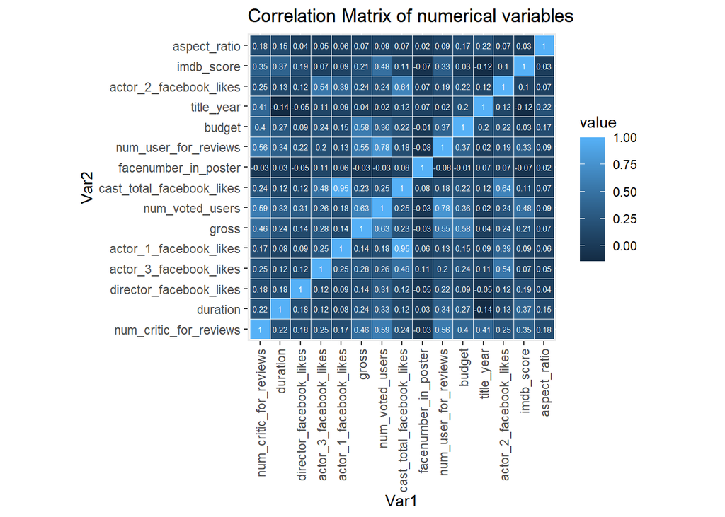

```r
ggplot(data = re_cormat, aes(x=Var1, y=Var2, fill=value)) +
  geom_tile(color = "white") +
  geom_text(aes(label = value), color = "white", size = 2) + # put the text values of each correlation
  theme(axis.text.x = element_text(angle = 90, vjust = 0.5, hjust=1)) + # rotate the x-label for easier reading
  coord_fixed() + # createline across each correlation
  labs(
    title = "Correlation Matrix of numerical variables",
    alt = "Heat Tile map of correlation in numerical values to show relationship between variables"
  )
```